# Warming Stripes

Wendy Anthony

09/05/2021

Based on 2018 code by Dominic Royé for [How to Create Warming Stripes in R](https://www.r-bloggers.com/how-to-create-warming-stripes-in-r/)

# Install Packages

`lubridate` for dates ymd( )  
`tidyverse` for ggplot2; stringr str_c( )  
`RColorBrewer` for colour scheme

## Load Libraries

```r
library("tidyverse")
library("lubridate")
library("RColorBrewer")
```

## Working Directory

```r
dir <- "/Users/wanthony/Documents/R/Climate-Weather"
setwd(dir)
getwd()
```

```
## [1] "/Users/wanthony/Documents/R/Climate-Weather"
```

# DATA

## import .csv file of monthly time-series data

Historical Data: Search for monthly Environment Canada Station Data  
* .csv file will need some data cleaning / manipulation before use * columns have monthly and seasonal values, and annual temperature value

```r
temp_victoria <- read_csv("VictoriaTemp-1941-2012.csv")
```

## get data info

```r
class(temp_victoria)
```

```
## [1] "spec_tbl_df" "tbl_df"      "tbl"         "data.frame"
```

```r
str(temp_victoria)
```

```
## spec_tbl_df[,18] [72 × 18] (S3: spec_tbl_df/tbl_df/tbl/data.frame)
##  $ Year   : num [1:72] 1941 1942 1943 1944 1945 ...
##  $ Jan    : num [1:72] 5.4 3.7 0.7 4.2 5.2 4.3 1.1 3.4 -0.6 -4.5 ...
##  $ Feb    : num [1:72] 6.5 4.8 5.3 4.7 5.2 5.1 5.4 3.2 2.2 3.5 ...
##  $ Mar    : num [1:72] 9 5.9 5.3 5.8 5.9 6 7.1 5 6.1 4.9 ...
##  $ Apr    : num [1:72] 11.4 9.3 9.6 9 7.7 8.1 9.7 7.7 8.4 7.4 ...
##  $ May    : num [1:72] 12.6 12.1 10.7 11.9 12.8 13.3 13.1 11.5 12.6 10 ...
##  $ Jun    : num [1:72] 14.5 14.6 14.1 14.8 13.9 13.9 14.7 15.5 14 14.7 ...
##  $ Jul    : num [1:72] 18 17.8 15.7 16.5 16.2 16.1 16.5 15.7 15.7 16.5 ...
##  $ Aug    : num [1:72] 16.3 18.1 16 16.2 16.1 16 15.4 15 15.4 15.7 ...
##  $ Sep    : num [1:72] 13.6 14.3 14.9 15.2 13.1 13.2 14.1 13.2 14.9 13.3 ...
##  $ Ovt    : num [1:72] 11.4 11 10.8 12.2 10.4 8.6 10.1 9.3 8.1 8.7 ...
##  $ Nov    : num [1:72] 7.9 5.9 7.3 7.4 5.4 4 5.7 5.7 8.8 5.7 ...
##  $ Dec    : num [1:72] 4.7 5.4 4.4 3.5 4.1 3.3 5.1 2.1 2.5 6.2 ...
##  $ D-J-F  : num [1:72] 5.5 4.6 3.5 4.1 4.8 4.2 3.9 2.9 1.4 1.7 ...
##  $ M-A-M  : num [1:72] 11 10.1 8.8 8.7 8.9 9 9.6 9 8.6 8.2 ...
##  $ J-J-A  : num [1:72] 16.3 16.8 15.3 15.8 15.4 15.3 15.5 15.4 15 15.6 ...
##  $ S-O-N  : num [1:72] 11 10.7 10.7 11.3 10.6 9.1 9.3 9.7 10 9.9 ...
##  $ YearAvg: num [1:72] 10.9 10.6 9.9 9.8 9.9 9.5 9.6 9.4 9 8.8 ...
##  - attr(*, "spec")=
##   .. cols(
##   ..   Year = col_double(),
##   ..   Jan = col_double(),
##   ..   Feb = col_double(),
##   ..   Mar = col_double(),
##   ..   Apr = col_double(),
##   ..   May = col_double(),
##   ..   Jun = col_double(),
##   ..   Jul = col_double(),
##   ..   Aug = col_double(),
##   ..   Sep = col_double(),
##   ..   Ovt = col_double(),
##   ..   Nov = col_double(),
##   ..   Dec = col_double(),
##   ..   `D-J-F` = col_double(),
##   ..   `M-A-M` = col_double(),
##   ..   `J-J-A` = col_double(),
##   ..   `S-O-N` = col_double(),
##   ..   YearAvg = col_double()
##   .. )
```

```r
head(temp_victoria)
```

```
## # A tibble: 6 x 18
##    Year   Jan   Feb   Mar   Apr   May   Jun   Jul   Aug   Sep   Ovt   Nov   Dec
##   <dbl> <dbl> <dbl> <dbl> <dbl> <dbl> <dbl> <dbl> <dbl> <dbl> <dbl> <dbl> <dbl>
## 1  1941   5.4   6.5   9    11.4  12.6  14.5  18    16.3  13.6  11.4   7.9   4.7
## 2  1942   3.7   4.8   5.9   9.3  12.1  14.6  17.8  18.1  14.3  11     5.9   5.4
## 3  1943   0.7   5.3   5.3   9.6  10.7  14.1  15.7  16    14.9  10.8   7.3   4.4
## 4  1944   4.2   4.7   5.8   9    11.9  14.8  16.5  16.2  15.2  12.2   7.4   3.5
## 5  1945   5.2   5.2   5.9   7.7  12.8  13.9  16.2  16.1  13.1  10.4   5.4   4.1
## 6  1946   4.3   5.1   6     8.1  13.3  13.9  16.1  16    13.2   8.6   4     3.3
## # … with 5 more variables: D-J-F <dbl>, M-A-M <dbl>, J-J-A <dbl>, S-O-N <dbl>,
## #   YearAvg <dbl>
```

## Select Columns: Year and Year Average temperature

```r
temp_victoria_yr <- select(temp_victoria,Year,YearAvg)
temp_victoria_yr
```

```
## # A tibble: 72 x 2
##     Year YearAvg
##    <dbl>   <dbl>
##  1  1941    10.9
##  2  1942    10.6
##  3  1943     9.9
##  4  1944     9.8
##  5  1945     9.9
##  6  1946     9.5
##  7  1947     9.6
##  8  1948     9.4
##  9  1949     9
## 10  1950     8.8
## # … with 62 more rows
```

## rename the temperature column

```r
temp_victoria_yr <- rename(temp_victoria_yr, TempMean=YearAvg)
temp_victoria_yr
```

```
## # A tibble: 72 x 2
##     Year TempMean
##    <dbl>    <dbl>
##  1  1941     10.9
##  2  1942     10.6
##  3  1943      9.9
##  4  1944      9.8
##  5  1945      9.9
##  6  1946      9.5
##  7  1947      9.6
##  8  1948      9.4
##  9  1949      9
## 10  1950      8.8
## # … with 62 more rows
```

### Check summary stats to see if data contains any missing values i.e. 999.9 (this would show as the max value)

```r
summary(temp_victoria_yr)
```

```
##       Year         TempMean
##  Min.   :1941   Min.   : 8.800
##  1st Qu.:1959   1st Qu.: 9.400
##  Median :1976   Median : 9.700
##  Mean   :1976   Mean   : 9.754
##  3rd Qu.:1994   3rd Qu.:10.100
##  Max.   :2012   Max.   :10.900
```

### Use the ifelse( ) function to replace missing values 999.9 with NA

```r
temp_victoria_yr <- mutate(temp_victoria_yr,
                           TempMean = ifelse(TempMean == 999.9, NA, TempMean))
temp_victoria_yr
```

```
## # A tibble: 72 x 2
##     Year TempMean
##    <dbl>    <dbl>
##  1  1941     10.9
##  2  1942     10.6
##  3  1943      9.9
##  4  1944      9.8
##  5  1945      9.9
##  6  1946      9.5
##  7  1947      9.6
##  8  1948      9.4
##  9  1949      9
## 10  1950      8.8
## # … with 62 more rows
```

# Convert year variable to a date object for ease of use with `Lubridate` and `ggplot2` packages

- tidyverse::str_c() function enables character combinations by specifiying a separator sep=“-”
- lubridate::ymd() function converts date character to Date object

```r
temp_victoria_yr <- mutate(temp_victoria_yr,
                           date = str_c(Year, "01-01", sep = "-") %>%
                           ymd())
temp_victoria_yr
```

```
## # A tibble: 72 x 3
##     Year TempMean date
##    <dbl>    <dbl> <date>
##  1  1941     10.9 1941-01-01
##  2  1942     10.6 1942-01-01
##  3  1943      9.9 1943-01-01
##  4  1944      9.8 1944-01-01
##  5  1945      9.9 1945-01-01
##  6  1946      9.5 1946-01-01
##  7  1947      9.6 1947-01-01
##  8  1948      9.4 1948-01-01
##  9  1949      9   1949-01-01
## 10  1950      8.8 1950-01-01
## # … with 62 more rows
```

# Create the Stripes

## Create default theme_minimal() style

```r
theme_strip <- theme_minimal()+
                 theme(axis.text.y = element_blank(),
                       axis.line.y = element_blank(),
                       axis.title = element_blank(),
                       panel.grid.major=element_blank(),
                       legend.title = element_blank(),
                       axis.text.x=element_text(vjust=3),
                       panel.grid.minor=element_blank(),
                       plot.title=element_text(size=14,face="bold")
                       )
```

## Assign colours using RColorBrewer

[ColorBrewer](https://colorbrewer2.org/)

```r
# get names of colours
brewer.pal.info
```

```
##          maxcolors category colorblind
## BrBG            11      div       TRUE
## PiYG            11      div       TRUE
## PRGn            11      div       TRUE
## PuOr            11      div       TRUE
## RdBu            11      div       TRUE
## RdGy            11      div      FALSE
## RdYlBu          11      div       TRUE
## RdYlGn          11      div      FALSE
## Spectral        11      div      FALSE
## Accent           8     qual      FALSE
## Dark2            8     qual       TRUE
## Paired          12     qual       TRUE
## Pastel1          9     qual      FALSE
## Pastel2          8     qual      FALSE
## Set1             9     qual      FALSE
## Set2             8     qual       TRUE
## Set3            12     qual      FALSE
## Blues            9      seq       TRUE
## BuGn             9      seq       TRUE
## BuPu             9      seq       TRUE
## GnBu             9      seq       TRUE
## Greens           9      seq       TRUE
## Greys            9      seq       TRUE
## Oranges          9      seq       TRUE
## OrRd             9      seq       TRUE
## PuBu             9      seq       TRUE
## PuBuGn           9      seq       TRUE
## PuRd             9      seq       TRUE
## Purples          9      seq       TRUE
## RdPu             9      seq       TRUE
## Reds             9      seq       TRUE
## YlGn             9      seq       TRUE
## YlGnBu           9      seq       TRUE
## YlOrBr           9      seq       TRUE
## YlOrRd           9      seq       TRUE
```

```r
## assign the colors from RColorBrewer to object col_srip.
col_strip <- brewer.pal(11,"RdBu")
```

# Create graphic with color-bar legend using ggplot2

- data doesn’t have a value for Y axis, so dummy value of 1 is used
- geometry used geom_tile()
- guide_colorbar(barwidth = 1) controls width of legend color bar

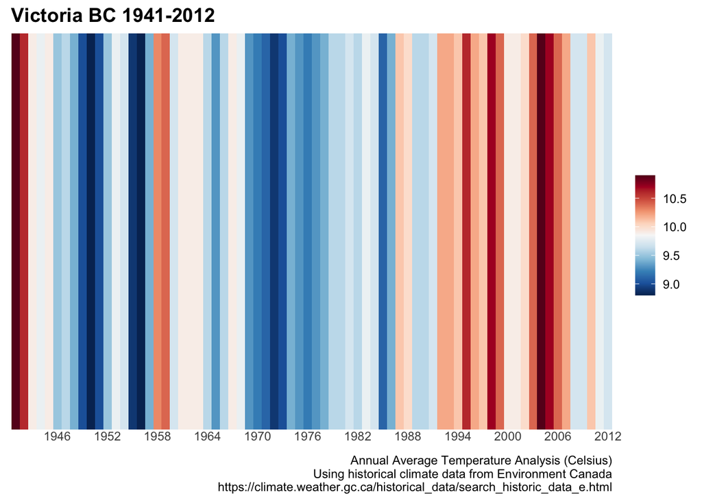

```r
## stripes plot with the legend
stplt_lg <- ggplot(temp_victoria_yr,
             aes(x = date, y = 1, fill = TempMean)) +
        geom_tile() +
           scale_x_date(date_breaks = "6 years",
                     date_labels = "%Y",
                     expand = c(0, 0)) +
           scale_y_continuous(expand = c(0, 0)) +
           scale_fill_gradientn(colors = rev(col_strip)) +
             guides(fill = guide_colorbar(barwidth = 1)) +
            labs(title = "Victoria BC 1941-2012",
                caption = "Annual Average Temperature Analysis (Celsius)\nUsing historical climate data from Environment Canada\nhttps://climate.weather.gc.ca/historical_data/search_historic_data_e.html") +
          theme_strip
stplt_lg
```

# Create image files with legend

```r
# png files have very poor resolution
png("VictoriaClimateStripes-1941-2012-lg.png")
stplt_lg
dev.off()
```

```r
# pdf files have better resolution
pdf("VictoriaClimateStripes-1941-2012-lg.pdf")
stplt_lg
dev.off()
```

```r
# tiff files have best resolution, with a larger file-size; specify size and resolution
tiff("VictoriaClimateStripes-1941-2012-lg.tiff", units="in", width=5, height=5, res=300)
stplt_lg
dev.off()
```

# Create graphic stripes only, without a color-bar legend

- geom_tile(show.legend = FALSE)
- use theme_void() to remove all theme styling
- NA values can have a different color by adding na.value = “gray70” to scale_fill_gradientn()

[figure not shown]

```r
stplt <- ggplot(temp_victoria_yr,
             aes(x = date, y = 1, fill = TempMean)) +
        geom_tile(show.legend = FALSE) +
           scale_x_date(date_breaks = "6 years",
                     date_labels = "%Y",
                     expand = c(0, 0)) +
           scale_y_discrete(expand = c(0, 0)) +
           scale_fill_gradientn(colors = rev(col_strip), na.value = "gray70") +
             theme_void()
stplt
```

# Create image files with no legend

```r
# png files have very poor resolution
png("VictoriaClimateStripes-1941-2012-lg.png")
stplt
dev.off()
```

```r
# pdf files have better resolution
pdf("VictoriaClimateStripes-1941-2012-lg.pdf")
stplt
dev.off()
```

```r
# tiff files have best resolution, with a larger file-size; specify size and resolution
tiff("VictoriaClimateStripes-1941-2012-lg.tiff", units="in", width=5, height=5, res=300)
stplt
dev.off()
```